# Simple Linear Regression with R

Mohamed El Fodil Ihaddaden

2019-12-04

In this tutorial, we’ll take a look at a simple linear model. We’ll use the `mpg` dataset which is linked to the `tidyverse` package.

```r
library(tidyverse)

head(mpg)
```

```
## # A tibble: 6 x 11
##   manufacturer model displ  year   cyl trans  drv     cty   hwy fl    class
##   <chr>        <chr> <dbl> <int> <int> <chr>  <chr> <int> <int> <chr> <chr>
## 1 audi         a4      1.8  1999     4 auto(~ f        18    29 p     comp~
## 2 audi         a4      1.8  1999     4 manua~ f        21    29 p     comp~
## 3 audi         a4      2    2008     4 manua~ f        20    31 p     comp~
## 4 audi         a4      2    2008     4 auto(~ f        21    30 p     comp~
## 5 audi         a4      2.8  1999     6 auto(~ f        16    26 p     comp~
## 6 audi         a4      2.8  1999     6 manua~ f        18    26 p     comp~
```

here, we’ll model the impact of `displ` (the independent variable : x) on `cty` (the dependent variable: y). We want to investigate if the energy efficiency as measured by `cty` is impacted by `displ`.

# First hypothesis: Linear relationship

In order to implement a linear regression, the relationship between *y* and *x* should be linear. Let’s check it out:

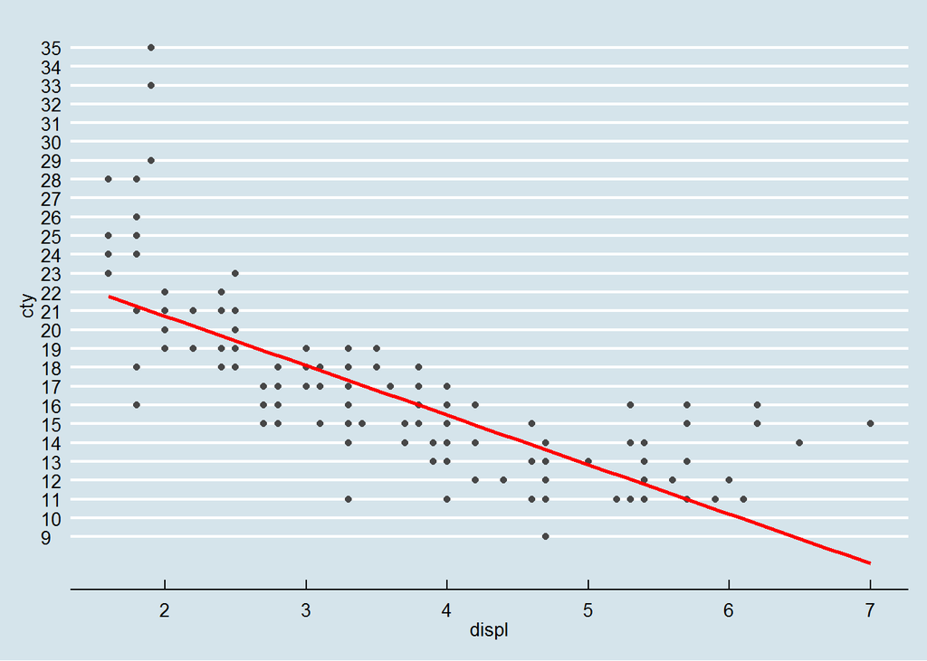

```r
ggplot(mpg, aes(displ, cty)) +
  geom_point(col = "grey28") +
  geom_smooth(method = "lm", se = FALSE, col = "red") + # plotting the regression line
  ggthemes::theme_economist()+
  scale_y_continuous(breaks = seq(min(mpg$cty), max(mpg$cty), 1))
```

From above, we can observe that there is a negative linear relationship between `disp` and `cty` nevertheless, we observe some outliers at the top left of our graph. Let’s remove them:

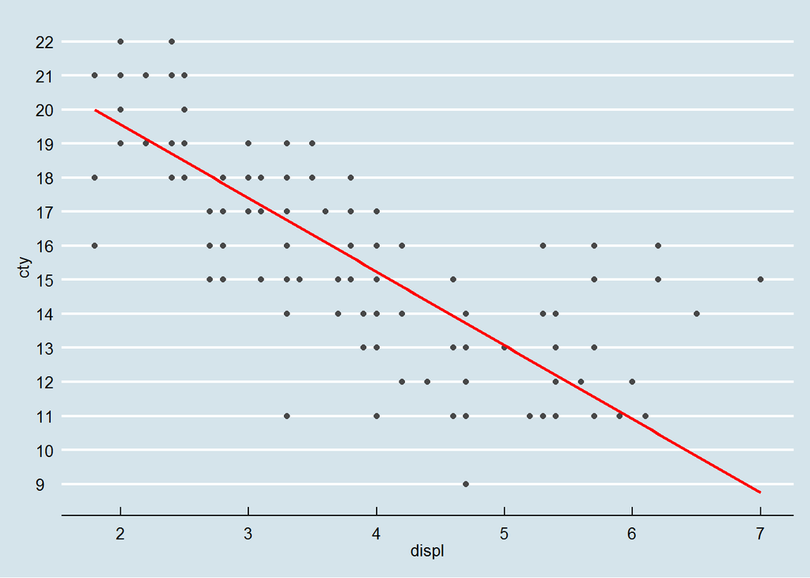

```r
mpg <- mpg %>% filter(cty < 23)


ggplot(mpg, aes(displ, cty)) +
  geom_point(col = "grey28") +
  geom_smooth(method = "lm", se = FALSE, col = "red") + # plotting the regression line
  ggthemes::theme_economist()+
  scale_y_continuous(breaks = seq(min(mpg$cty), max(mpg$cty), 1))
```

much better !!!

# Second hypothesis: good level of association

When running a linear regression, a good level of correlation is preferable. We can measure the pearson correlation using the `cor()` function:

```r
cor(mpg$displ, mpg$cyl)
```

```
## [1] 0.9223959
```

# Fitting the model to our data

In order to fit our model, we’ll use the `lm()` function as follows:

```r
my_model <- lm(cty ~ displ, data = mpg)
```

# Extracting the regression information

Using the `summary()` function, we’ll investigate the results of our regression:

```r
summary(my_model)
```

```
##
## Call:
## lm(formula = cty ~ displ, data = mpg)
##
## Residuals:
##     Min      1Q  Median      3Q     Max
## -5.7549 -1.2060 -0.0724  1.4292  6.2598
##
## Coefficients:
##             Estimate Std. Error t value Pr(>|t|)
## (Intercept)  23.9031     0.3977   60.10   <2e-16 ***
## displ        -2.1661     0.1042  -20.79   <2e-16 ***
## ---
## Signif. codes:  0 '***' 0.001 '**' 0.01 '*' 0.05 '.' 0.1 ' ' 1
##
## Residual standard error: 1.909 on 214 degrees of freedom
## Multiple R-squared:  0.6688, Adjusted R-squared:  0.6673
## F-statistic: 432.2 on 1 and 214 DF,  p-value: < 2.2e-16
```

We remark that our predictor has a p-value < 1%, therefore we can reject the Null hypothesis and say that according to our data the `disp` variable has a **significant** impact on fuel efficiency. The formula of our model can be written as: $cty = 23.9031 - 2.1661 \times displ$